# Practical Machine Learning

Daniel Sobrado

Sunday, April 19, 2015

## Summary

Smart wearable devices like Jawbone Up, Nike FuelBand, and Fitbit allows people to record their physical activity easily. However, few research was conducted on the quality of recorded physical activity. This analysis involved 6 participants, who were asked to perform barbell lifts correctly and incorrectly in 5 different ways. The machine learning algorithm developed based on the recorded data could distinguish the types of barbell lifts very well.

## Preparation

```r
setwd("C:\\Workspaces\\workspace_R\\predmachlearn")

library(ElemStatLearn, quietly=TRUE)
library(data.table, quietly=TRUE)
library(randomForest, quietly=TRUE)
library(caret, quietly=TRUE)
library(tree, quietly=TRUE)
```

Make the test reproducible.

```r
set.seed(222)
```

## Pre-processing and cleaning

we load the pre-processed data and perform some exploratory analysis

```r
training <- read.csv("pml-training.csv", na.strings=c("", "NA", "NULL"))
testingIn <- read.csv("pml-testing.csv", na.strings=c("", "NA", "NULL"))
```

# Cleaning the data

cleaning precedures were applied.

```r
trainingClean <- training[ , colSums(is.na(training)) == 0]
testingInClean <- testingIn[ , colSums(is.na(testingIn)) == 0]

dim(trainingClean)
```

```
## [1] 19622    60
```

```r
dim(testingInClean)
```

```
## [1] 20 60
```

Removing extra columns

```r
removeCols = c('X', 'user_name', 'raw_timestamp_part_1', 'raw_timestamp_part_2', 'cvtd_timestamp', 'new_window', 'num_window')
trainingClean <- trainingClean[, -which(names(trainingClean) %in% removeCols)]
testingInClean <- testingInClean[, -which(names(testingInClean) %in% removeCols)]
dim(trainingClean)
```

```
## [1] 19622    53
```

## Correlations

Calculate correlations and plot a heatmap.

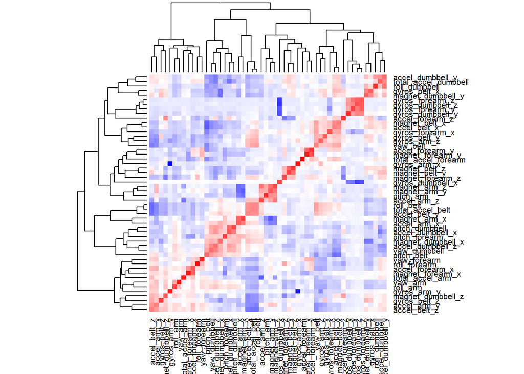

```r
resultsCorrelation <- cor(trainingClean[, names(trainingClean) != 'classe'])
palette <- colorRampPalette(c('blue', 'white', 'red'))(n = 199)
heatmap(resultsCorrelation, col = palette)
```

```r
resultsCorrelation[(resultsCorrelation < -0.9 | resultsCorrelation > 0.9) & resultsCorrelation != 1]
```

```
##  [1]  0.9809241  0.9248983 -0.9920085 -0.9657334  0.9809241  0.9278069
##  [7] -0.9749317 -0.9657334  0.9248983  0.9278069 -0.9333854 -0.9920085
## [13] -0.9749317 -0.9333854 -0.9181821 -0.9181821 -0.9789507 -0.9144764
## [19] -0.9789507  0.9330422 -0.9144764  0.9330422
```

## Partitioning

we’ll put 60% for training and 40% for testing

```r
partition <- createDataPartition(y=trainingClean$classe, p=0.6, list=FALSE)
trainingPart <- trainingClean[partition,]
testingPart <- trainingClean[-partition,]
```

The resulted training sub-group contains 11776 observations while the testing contains 7846.

Let’s see a summary tree.

```r
trainingTree <- tree(classe~.,data=trainingPart)
summary(trainingTree)
```

```
##
## Classification tree:
## tree(formula = classe ~ ., data = trainingPart)
## Variables actually used in tree construction:
##  [1] "roll_belt"            "pitch_forearm"        "roll_forearm"
##  [4] "magnet_dumbbell_x"    "magnet_dumbbell_y"    "magnet_dumbbell_z"
##  [7] "pitch_belt"           "yaw_belt"             "accel_forearm_z"
## [10] "total_accel_dumbbell" "accel_forearm_x"
## Number of terminal nodes:  17
## Residual mean deviance:  1.717 = 20190 / 11760
## Misclassification error rate: 0.3336 = 3928 / 11776
```

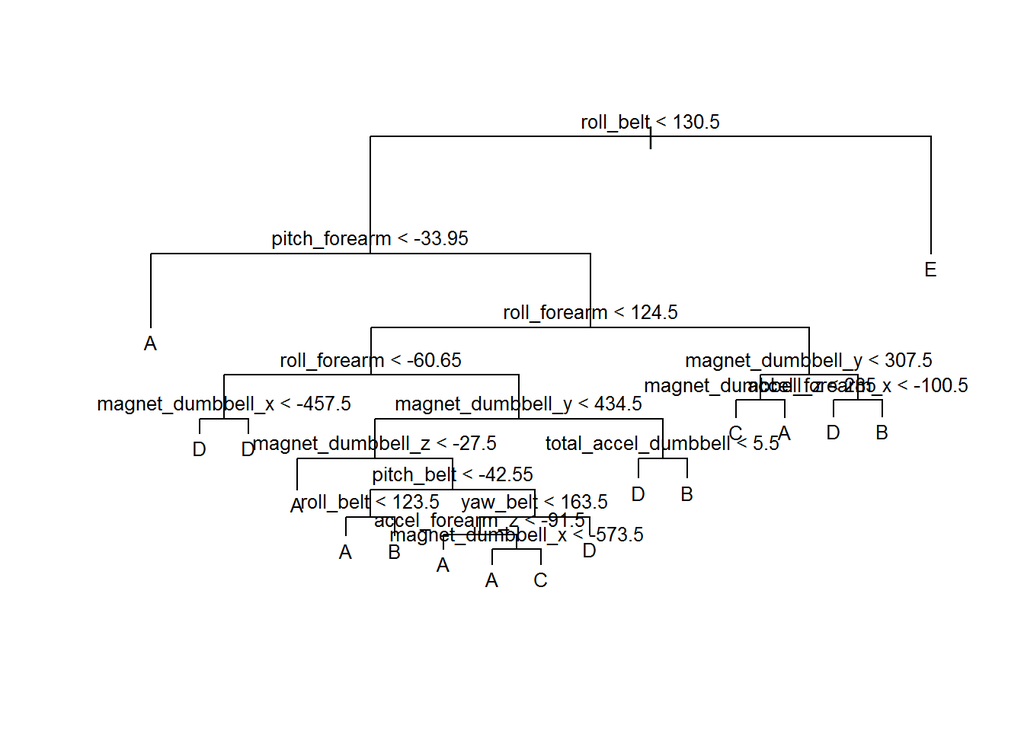

```r
plot(trainingTree)
text(trainingTree,pretty=0, cex = .8)
```

# Use Random Forest

Our prdiction method will be a Random Forest

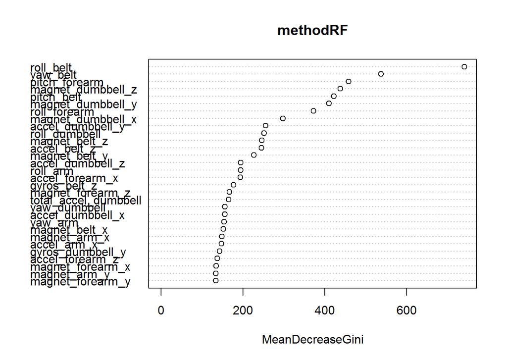

```r
methodRF <- randomForest(classe ~ ., data = trainingPart, proximity=TRUE)

varImpPlot(methodRF,)
```

# Results

```r
results <- predict(methodRF, newdata = testingInClean)
results
```

```
##  1  2  3  4  5  6  7  8  9 10 11 12 13 14 15 16 17 18 19 20
##  B  A  B  A  A  E  D  B  A  A  B  C  B  A  E  E  A  B  B  B
## Levels: A B C D E
```

# Write Results

```r
pml_write_files = function(x){
  n = length(x)
  for(i in 1:n){
    filename = paste0("problem_id_",i,".txt")
    write.table(x[i],file=filename,quote=FALSE,row.names=FALSE,col.names=FALSE)
  }
}

pml_write_files(results)
```